# Term Project-PartII- analyze Federal Election Commission data

Shyni David

December 4, 2018

Import and analyze Federal Election Commission data contained in the four files listed below, and report your findings in a short write-up (no more than a few paragraphs). The topic is up to you. I recognize that this is a bit open ended, but I’d like you to play with the data, identify an interesting question/topic and apply skills you learned in this course to shed light on it. A good deliverable will- 1. discuss an interesting and well-motivated topic 2. involve some non-trivial data wrangling (e.g., joins) 3. provide a well-though-out, informative analysis 4. convey some sort of insight

Load Libraries

```r
#install.packages("dplyr")
library(dplyr)
#install.packages("sqldf")
library(sqldf)
```

```r
library(ggplot2)
```

Load the files

```r
load("C:/Users/theda/Desktop/FISHER SMB-A/Term 2/Data Management for Analytics/Term Project week 3 4/Term Project PArt 2/house_elections.rda")

load("C:/Users/theda/Desktop/FISHER SMB-A/Term 2/Data Management for Analytics/Term Project week 3 4/Term Project PArt 2/contributions.rda")

load("C:/Users/theda/Desktop/FISHER SMB-A/Term 2/Data Management for Analytics/Term Project week 3 4/Term Project PArt 2/committees.rda")

load("C:/Users/theda/Desktop/FISHER SMB-A/Term 2/Data Management for Analytics/Term Project week 3 4/Term Project PArt 2/candidates.rda")
```

Questions analysed 1. How many incumbant candidates are winners, in which year and to which party they belong to? Ratio of incumbent, challenger and open seat winners.

```r
win_cand <- sqldf("select cand_id, cand_name, cand_party_affiliation, cand_election_yr, cand_office_state, b.ge_winner, cand_ici from candidates, house_elections b  where b.fec_id = cand_id and b.ge_winner = 'W' group by state order by  cand_state")

wy <- sqldf("select distinct(cand_election_yr) from win_cand")
paste("The files has winning candidates of year", wy)
```

```
## [1] "The files has winning candidates of year 2012"
```

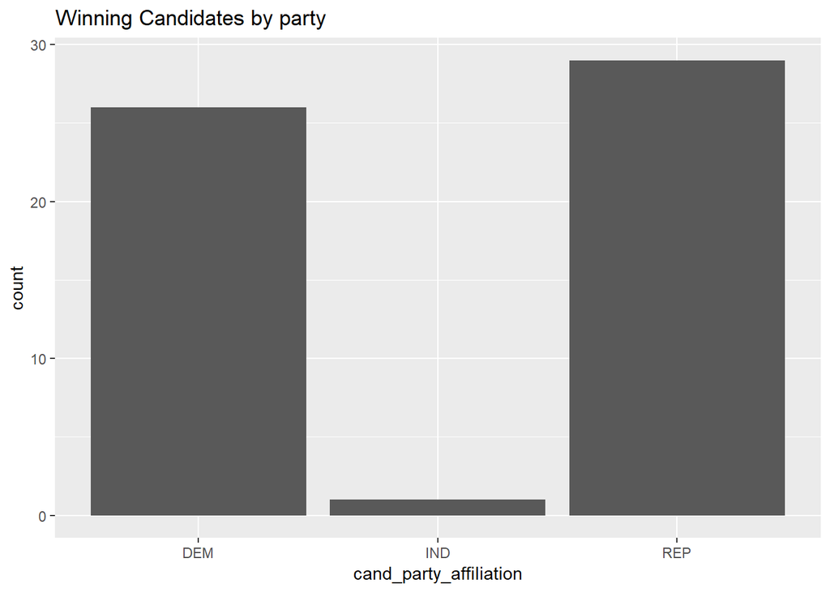

```r
ggplot(win_cand, aes(cand_party_affiliation)) + geom_bar( ) + labs(title = "Winning Candidates by party")
```

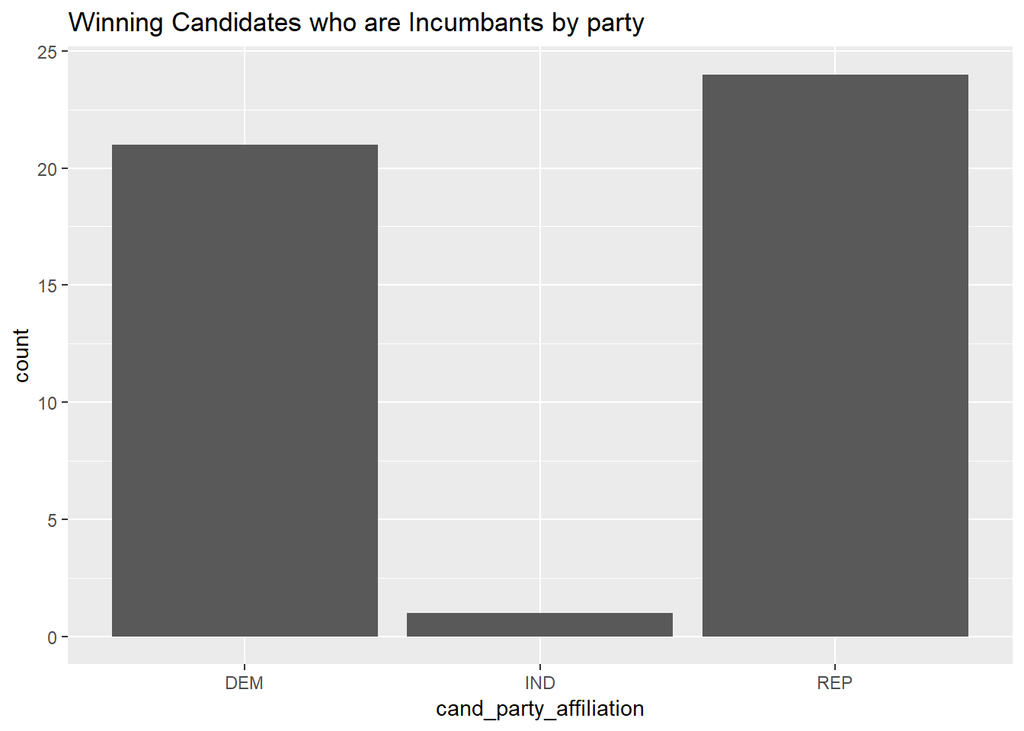

```r
ic <- sqldf("select * from win_cand where cand_ici = 'I'")
  ggplot(ic, aes(cand_party_affiliation)) + geom_bar( ) + labs(title = "Winning Candidates who are Incumbants by party")
```

```r
  #Total number of candidates
ica <- sqldf("select count(*)  from candidates")

#I = Incumbent candidate
ici <- sqldf("select count(*)  from win_cand where cand_ici = 'I'")
#O- O = Open Seat candidate
ico <- sqldf("select count(*)  from win_cand where cand_ici = 'O'")
#C = Challenger candidate
icc <- sqldf("select count(*)  from win_cand where cand_ici = 'C'")

#percent of winner candidates who are incumbent
p1 <- (ici / ica ) * 100
paste(round(p1, digits = 2), "% of winner candidates are Incumbents.")
```

```
## [1] "0.82 % of winner candidates are Incumbents."
```

```r
#percent of winner candidate who are Challenger
p2 <- (icc / ica ) * 100
paste(round(p2, digits = 2), "% of winner candidates are Challengers.")
```

```
## [1] "0.09 % of winner candidates are Challengers."
```

```r
# percent of open seat candidate who winners
p3 <- (ico / ica ) * 100
paste(round(p3, digits = 2), "% of winner candidates are Open seat candidates.")
```

```
## [1] "0.09 % of winner candidates are Open seat candidates."
```

```r
sqldf("select count(*) from candidates where cand_ici = 'O'")
```

```
##   count(*)
## 1     1120
```

```r
sqldf("select count(*) from win_cand where cand_ici = 'C'")
```

```
##   count(*)
## 1        5
```

2. What is the relationship between committee, candidate and contribution by state and if the candidates are winners and belong to which party?
- which committee had the highest contribution and in which state?

```r
candcont <- sqldf("select cand_id, transaction_amt, cmte_id from contributions ")
colnames(candcont) <- c("cand_id", "txn_amt", "cmte_id")
candcont1 <- sqldf("select a.cand_id, a.cand_name, a.cand_party_affiliation, b.txn_amt, a.cand_office_state,b.cmte_id  from candidates a, candcont b where a.cand_id = b.cand_id order by a.cand_id")

candcont2 <- candcont1 %>% select(cand_id, cand_name, cand_party_affiliation, cand_office_state, txn_amt) %>% group_by(cand_id, cand_name, cand_party_affiliation, cand_office_state) %>% summarize(transaction_amt = sum(txn_amt))

candcont2[which.max(candcont2$transaction_amt),]
```

```
## # A tibble: 1 x 5
## # Groups:   cand_id, cand_name, cand_party_affiliation [1]
##   cand_id  cand_name   cand_party_affili~ cand_office_sta~ transaction_amt
##   <chr>    <chr>       <chr>              <chr>                      <dbl>
## 1 P800033~ OBAMA, BAR~ DEM                US                     398245641
```

```r
paste("The candidate who received the maximum contribution is", candcont2$cand_name, "and represents", candcont2$cand_party_affiliation)
```

[output not shown]

[output cut: 1718 more lines]

```r
candcont3 <- sqldf("select b.cand_id, b.cand_name, b.txn_amt, b.cand_office_state,b.cmte_id , a.cmte_name from committees a, candcont1 b where a.cand_id = b.cand_id order by a.cand_id")

candcont4 <- candcont3[which.max(candcont3$txn_amt),]
paste("The committee that contributed the maximum donation is", candcont4$txn_amt, "and the candiate is", candcont4$cand_name )
```

```
## [1] "The committee that contributed the maximum donation is 9856374 and the candiate is OBAMA, BARACK"
```